# MTH6139 Time Series

Brighton&Hove Albion Match Attendance

George Porter

Spring term 2025

# **Introduction** —–

I have chosen to analyse the Premier League club Brighton&Hove Albion’s attendance figures for this coursework. However upon researching the data it has been made clear that generally the home attendance figures at the clubs stadium (called the Amex Stadium) has little variation around the max capacity of 31,876. Reflecting on this I then considered analysing a subset of this data, perhaps focusing on Away attendance(number of spectators when playing at opposing teams stadiums). I fear that this would be heavily dependant on the capacity of those stadiums as well however, so i think a more interesting idea would be to model each away game as a percentage of that stadiums average in order to determine the “attractiveness” of Brighton FC as an away game, and then we could forecast that percentage to see trends in club popularity.

# **Data Frame Creation** ——————————————————–

We will start with creating our dataframe, I have used fbref https://fbref.com/en/squads/d07537b9/Brighton-and-Hove-Albion-Stats#all_matchlogs to compile Brighton’s match data and attendance numbers, as well as https://www.transfermarkt.co.uk/premier-league/besucherzahlen/pokalwettbewerb/GB1 transfer markt to find information on each stadium.

```r
away_dates = c("2025-08-24","2025-08-27","2025-09-13","2025-09-23","2025-09-27",
               "2025-10-05","2025-10-25","2025-10-29","2025-11-09","2025-11-30",
               "2025-12-13","2025-12-27","2025-12-30","2026-01-07","2026-01-11",
               "2026-01-24","2026-02-11","2026-02-14","2026-02-21","2026-03-14")
away_opponents = c("Everton","Oxford United","Bournemouth","Barnsley","Chelsea",
                   "Wolves","Manchester Utd","Arsenal","Crystal Palace",
                   "Nottingham Forest","Liverpool","Arsenal","West Ham",
                   "Manchester City","Manchester Utd","Fullham","Aston Villa",
                   "Liverpool","Brentford","Sunderland")
attendance = c(51759,9010,11167,7790,39597,29504,74124,59292,24326,30522,60429,
               60209,62464,51728,73888,27239,39495,60277,17163,45497)

Brighton_Away = data.frame(date=as.Date(away_dates),Opponent=away_opponents,
                           Attendance= attendance,stringsAsFactors=FALSE)
print (Brighton_Away)
```

```
##          date          Opponent Attendance
## 1  2025-08-24           Everton      51759
## 2  2025-08-27     Oxford United       9010
## 3  2025-09-13       Bournemouth      11167
## 4  2025-09-23          Barnsley       7790
## 5  2025-09-27           Chelsea      39597
## 6  2025-10-05            Wolves      29504
## 7  2025-10-25    Manchester Utd      74124
## 8  2025-10-29           Arsenal      59292
## 9  2025-11-09    Crystal Palace      24326
## 10 2025-11-30 Nottingham Forest      30522
## 11 2025-12-13         Liverpool      60429
## 12 2025-12-27           Arsenal      60209
## 13 2025-12-30          West Ham      62464
## 14 2026-01-07   Manchester City      51728
## 15 2026-01-11    Manchester Utd      73888
## 16 2026-01-24           Fullham      27239
## 17 2026-02-11       Aston Villa      39495
## 18 2026-02-14         Liverpool      60277
## 19 2026-02-21         Brentford      17163
## 20 2026-03-14        Sunderland      45497
```

```r
Brighton_Away$stringAsFactors = NULL
```

Now I will add the stadium names, averages and capacities into the data frame by creating stadium lookup vectors and information columns

```r
stadium_opponent = c("Everton","Oxford United","Bournemouth","Barnsley","Chelsea",
                     "Wolves","Manchester Utd","Arsenal","Crystal Palace",
                     "Nottingham Forest","West Ham",
                     "Manchester City","Fullham","Aston Villa",
                     "Liverpool","Brentford","Sunderland")
stadium_name = c("Hill Dickinson Stadium","Kassum Stadium","Vitality Stadium","Oakwell Stadium"
                  ,"Stamford Bridge","Molineux Stadium","Old Trafford","Emirates Stadium",
                 "Selhurst Park","The City Ground","London Stadium","Etihad Stadium",
                 "Craven Cottage","Villa Park","Anfield","Gtech Stadium","Stadium of Light")
stadium_cap = c(52769,12500,11307,23287,41631,31750,74879,60704,25486,30404,62500,
                55097,29589,42918,61276,17250,48707)
stadium_avg = c(52035,11358,11167,12211,39680,29830,73979,60216,24887,30334,62453,
                52206,27156,41802,60395,17094,46323)
stadium_lookup = data.frame(
    opponent = stadium_opponent,
    stadium = stadium_name,
    capacity = stadium_cap,
    avg_attendance = stadium_avg,
    stringAsFactors = FALSE
)
Brighton_Away = merge(
    Brighton_Away,
    stadium_lookup,
    by.x = "Opponent",
    by.y = "opponent",
    all.x = TRUE,
    sort = FALSE
) # merged Brighton away and stadium info using the column for opponents

# reorder by date as merge has aligned by opponent name
# also add a match number since row number is not chronological any more

Brighton_Away = Brighton_Away[order(Brighton_Away$date),]
Brighton_Away$match_number = 1:nrow(Brighton_Away)
```

Now we calculate a demand or attractiveness score which compares Brighton’s attendance to the average.

```r
Brighton_Away$demand_index = (Brighton_Away$Attendance / Brighton_Away$avg_attendance) * 100
Brighton_Away$demand_index = round(Brighton_Away$demand_index, 0.1)
Brighton_Away$month = format(Brighton_Away$date, "%B")
Brighton_Away$day_of_week = weekdays(Brighton_Away$date)
```

To use prophet we need this in a format with a DS column and y column so: I had issues creating this data frame all at once so I had to construct it incrementally, I do not know why this worked but not the other way.

```r
df_prophet = data.frame(ds = Brighton_Away$date, stringsAsFactors = FALSE)
df_prophet$y = Brighton_Away$demand_index
df_prophet$opponent = Brighton_Away$Opponent
df_prophet$stadium = Brighton_Away$stadium
df_prophet$attendance = Brighton_Away$Attendance
df_prophet$avg_attendance = Brighton_Away$avg_attendance
df_prophet$opponent_category = Brighton_Away$opponent_category
df_prophet$month = Brighton_Away$month
df_prophet$day_of_week = Brighton_Away$day_of_week
df_prophet$match_number = Brighton_Away$match_number
```

# **Plotting** ——————————————————————

This is putting our dataframe into prophet

```r
library(prophet)
m = prophet(df_prophet)
```

```
## Disabling yearly seasonality. Run prophet with yearly.seasonality=TRUE to override this.
```

```
## Disabling daily seasonality. Run prophet with daily.seasonality=TRUE to override this.
```

```
## n.changepoints greater than number of observations. Using 15
```

Here I am creating a sequence of the months we’re plotting over, in order to label our axis.

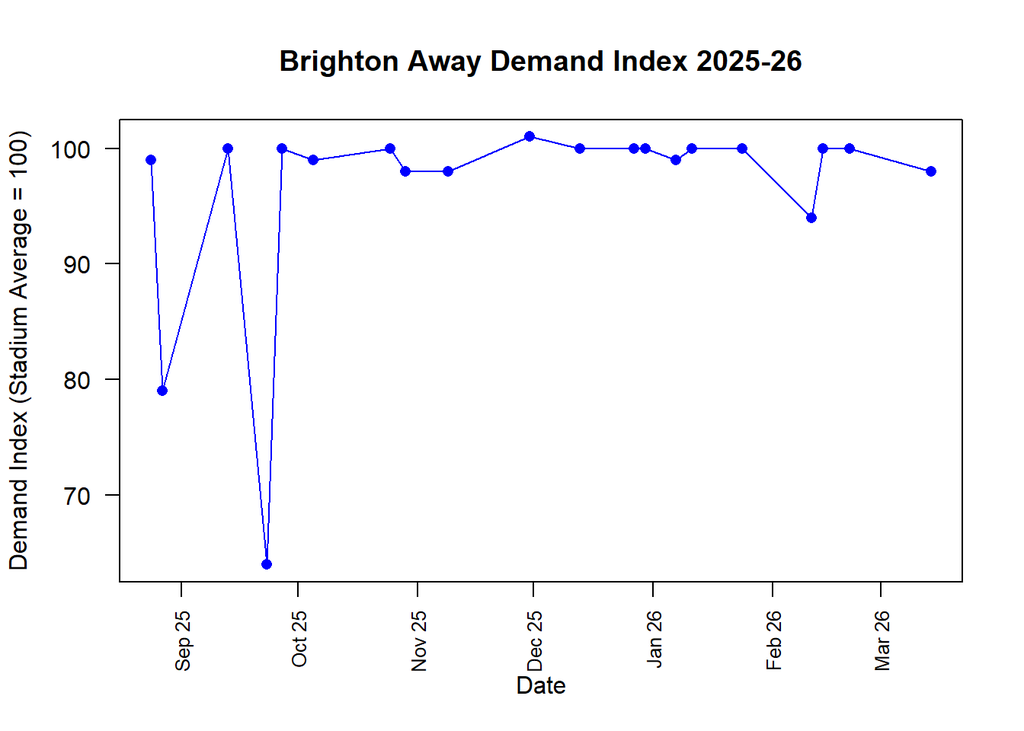

```r
month_starts = seq(from = as.Date("2025-08-01"),
                   to = as.Date("2026-06-01"),
                   by = "month")
month_labels = format(month_starts, "%b %y")

plot(df_prophet$ds, df_prophet$y,
     type = "o",
     main = "Brighton Away Demand Index 2025-26",
     xlab = "Date",
     ylab = "Demand Index (Stadium Average = 100)",
     col = "blue",
     pch = 16,
     las = 2,
     xaxt = "n")
axis(1, at = month_starts, labels = month_labels, las = 2, cex.axis = 0.8)
```

Note we have two big outliers in Barnsley and Oxford, which is notable as these are FA cup games where Brighton played lower league teams, probably resulting in lower attendance from home fans due to unfair odds

Now we will make future predictions as well as historical, so we can analyse fit of our model to make comments about accuracy.

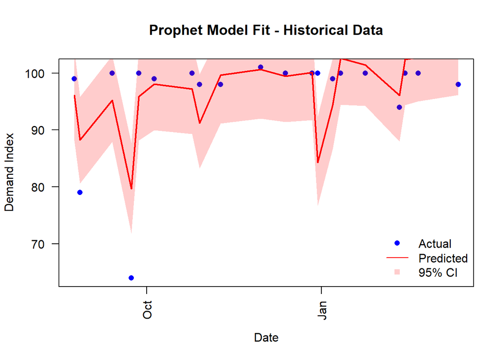

```r
historical = predict(m, df_prophet)
plot(df_prophet$ds, df_prophet$y,
     type = "p",
     main = "Prophet Model Fit - Historical Data",
     xlab = "Date",
     ylab = "Demand Index",
     col = "blue",
     pch = 16,
     las = 2)
lines(df_prophet$ds, historical$yhat,
      col = "red",
      lwd = 2)
polygon(c(df_prophet$ds, rev(df_prophet$ds)),
        c(historical$yhat_upper, rev(historical$yhat_lower)),
        col = rgb(1, 0, 0, 0.2),
        border = NA)
legend("bottomright",
       legend = c("Actual", "Predicted", "95% CI"),
       col = c("blue", "red", rgb(1, 0, 0, 0.2)),
       pch = c(16, NA, 15),
       lty = c(NA, 1, NA),
       bty = "n")
```

this shows us what the model predicts for the data points we already have, as a reference for the models ability. Generally it is on point or at least within the confidence interval shown, however I believe it is slipping up due to our outliers. Later we will re-plot without them to see how the model adjusts.

Brighton have only 4 remaining away games this season, lets predict their demand index.

```r
n_remaining = 4
remaining_dates = as.Date(c("2026-04-11","2026-04-18","2026-05-02","2026-05-17"))
future = data.frame(ds = remaining_dates)
forecast = predict(m, future)
forecast$ds = as.Date(forecast$ds) #needed to standardise date format to plot
```

combine the forecast and historic data to plot a graph.

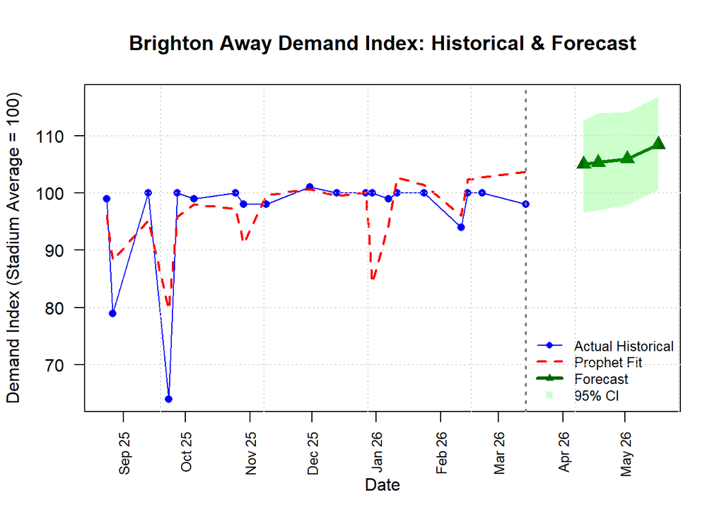

```r
all_dates <- c(df_prophet$ds, forecast$ds)
all_predictions <- c(historical$yhat, forecast$yhat)
all_lower <- c(historical$yhat_lower, forecast$yhat_lower)
all_upper <- c(historical$yhat_upper, forecast$yhat_upper)

plot(df_prophet$ds, df_prophet$y,
     type = "o",
     main = "Brighton Away Demand Index: Historical & Forecast",
     xlab = "Date",
     ylab = "Demand Index (Stadium Average = 100)",
     col = "blue",
     pch = 16,
     xlim = range(all_dates),
     ylim = range(c(df_prophet$y, all_upper, all_lower)),
     las = 2,
     xaxt = "n")
axis(1, at = month_starts, labels = month_labels, las = 2, cex.axis = 0.8)


lines(df_prophet$ds, historical$yhat, col = "red", lty = 2, lwd = 2)
lines(forecast$ds, forecast$yhat, col = "darkgreen", lwd = 3)
points(forecast$ds, forecast$yhat, col = "darkgreen", pch = 17, cex = 1.5)

polygon(c(forecast$ds, rev(forecast$ds)),
        c(forecast$yhat_upper, rev(forecast$yhat_lower)),
        col = rgb(0, 1, 0, 0.2),
        border = NA) #this is the confidence interval on forecast data
abline(v = max(df_prophet$ds), col = "gray50", lty = 3, lwd = 2) #mark end of recorded data
legend("bottomright",
       legend = c("Actual Historical", "Prophet Fit", "Forecast", "95% CI"),
       col = c("blue", "red", "darkgreen", rgb(0, 1, 0, 0.2)),
       lty = c(1, 2, 1, NA),
       lwd = c(1, 2, 3, NA),
       pch = c(16, NA, 17, 15),
       bty = "n",
       cex = 0.8)

grid() # looks nice and helps visualise the data.
```

there is a large gap between the plot and the forecast, but it is because Brighton don’t have an away game for almost a month between 14th March and 11th April

Observing the forecast I do believe it is significantly impacted by the outliers and suggesting there is growth patterns, resulting in the future data being above 100 on the demand index. I expect if we remove the outliers the data should be more in line, and present less than or equal to 100. Not to say that values of 100 aren’t valid, merely not in line with the data.

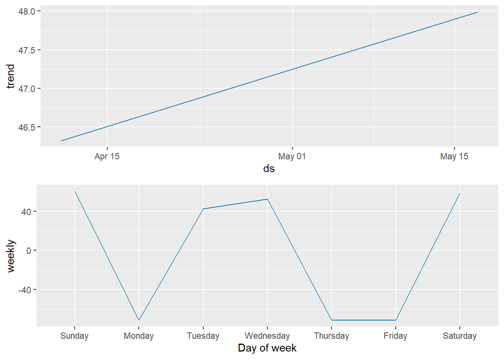

```r
prophet_plot_components(m, forecast)
```

# **Cleaning the Data** ———————————————————

the matches we want to remove are number 2 and 4:

```r
df_clean = df_prophet[!df_prophet$match_number %in% c(2,4),]
```

we could reset our match numbers, but I’m choosing not to to retain clarity, as I’m keeping the other FA cup matches with premier league teams.

```r
print(df_clean)
```

```
##            ds   y          opponent                stadium attendance
## 1  2025-08-24  99           Everton Hill Dickinson Stadium      51759
## 3  2025-09-13 100       Bournemouth       Vitality Stadium      11167
## 5  2025-09-27 100           Chelsea        Stamford Bridge      39597
## 6  2025-10-05  99            Wolves       Molineux Stadium      29504
## 7  2025-10-25 100    Manchester Utd           Old Trafford      74124
## 8  2025-10-29  98           Arsenal       Emirates Stadium      59292
## 9  2025-11-09  98    Crystal Palace          Selhurst Park      24326
## 10 2025-11-30 101 Nottingham Forest        The City Ground      30522
## 11 2025-12-13 100         Liverpool                Anfield      60429
## 12 2025-12-27 100           Arsenal       Emirates Stadium      60209
## 13 2025-12-30 100          West Ham         London Stadium      62464
## 14 2026-01-07  99   Manchester City         Etihad Stadium      51728
## 15 2026-01-11 100    Manchester Utd           Old Trafford      73888
## 16 2026-01-24 100           Fullham         Craven Cottage      27239
```

[output cut: 23 more lines]

```r
df_prophet_clean = prophet(df_clean)
```

```
## Disabling yearly seasonality. Run prophet with yearly.seasonality=TRUE to override this.
```

```
## Disabling daily seasonality. Run prophet with daily.seasonality=TRUE to override this.
```

```
## n.changepoints greater than number of observations. Using 13
```

```r
forecast_clean = predict(df_prophet_clean, future)
forecast_clean$ds = as.Date(forecast_clean$ds)
historical_clean = predict(df_prophet_clean, df_clean)
historical_clean$ds = as.Date(historical_clean$ds)
```

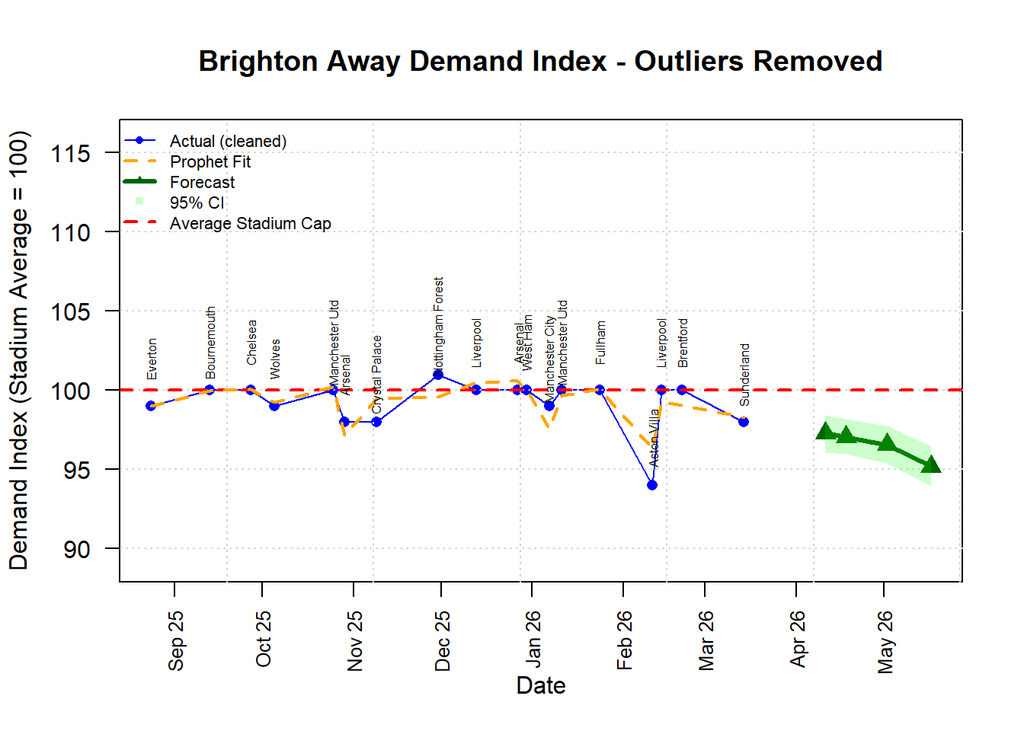

```r
plot(df_clean$ds, df_clean$y,
     type = "o",
     main = "Brighton Away Demand Index - Outliers Removed",
     xlab = "Date",
     ylab = "Demand Index (Stadium Average = 100)",
     col = "blue",
     pch = 16,
     xaxt = "n",
     las = 2,
     xaxt = "n",
     ylim = range(c(df_clean$y, forecast_clean$yhat)) + c(-5, 15),
     xlim = range(c(df_clean$ds, forecast_clean$ds)))
axis(1, at = month_starts, labels = month_labels, las = 2, cex.axis = 0.8)
grid()
abline(h = 100, col = "red", lty = 2, lwd = 2)
lines(historical_clean$ds, historical_clean$yhat, col = "orange", lty = 2, lwd = 2)
lines(forecast_clean$ds, forecast_clean$yhat, col = "darkgreen", lwd = 3)
points(forecast_clean$ds, forecast_clean$yhat, col = "darkgreen", pch = 17, cex = 1.5)
polygon(c(forecast_clean$ds, rev(forecast_clean$ds)),
        c(forecast_clean$yhat_upper, rev(forecast_clean$yhat_lower)),
        col = rgb(0, 1, 0, 0.2),
        border = NA)
text(df_clean$ds, df_clean$y + 3,
     labels = df_clean$opponent,
     cex = 0.5,
     col = "black",
     srt = 90)
legend("topleft",
       legend = c("Actual (cleaned)", "Prophet Fit", "Forecast", "95% CI", "Average Stadium Cap"),
       col = c("blue", "orange", "darkgreen", rgb(0, 1, 0, 0.2), "red"),
       lty = c(1, 2, 1, NA, 2),
       lwd = c(1, 2, 3, NA, 2),
       pch = c(16, NA, 17, 15, NA),
       bty = "n",
       cex = 0.7)
```

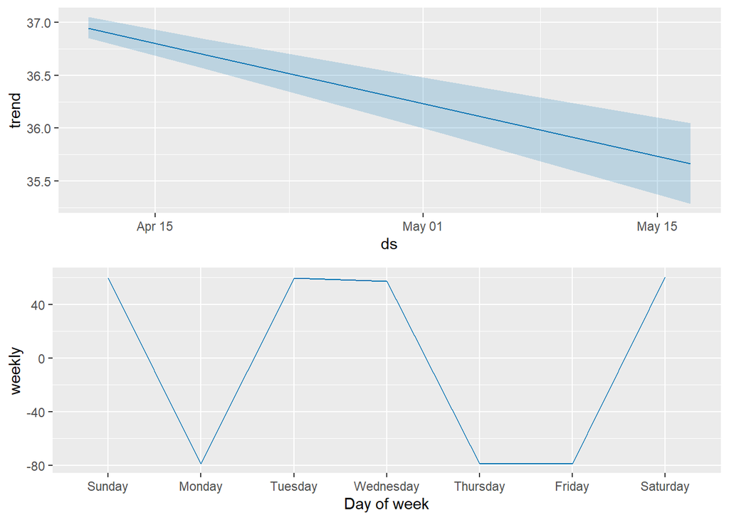

```r
prophet_plot_components(df_prophet_clean, forecast_clean)
```

here we see the same variation between weekends and weekdays. However the trend has flipped completely, and now is declining. Without the extremely negative values of our outliers, we see that in truth the demand for Brighton away games is falling, likely due to end of season and the fact that Brighton are finishing in the middle of the league. Demand might pick up if the club was at either end as there would be excitement to watch them fight for the top positions or avoid being relegated at the bottom of the league.